# Risk Factor Analysis

## Outcome Variable

**Outcome Variable:** wasted

## Predictor Variables

**Intervention Variable:** hhwealth_quart

**Adjustment Set:**

- arm
- sex
- W_mage
- meducyrs
- feducyrs
- W_gagebrth
- W_birthwt
- W_birthlen
- W_nchldlt5
- W_parity
- delta_W_mage
- delta_meducyrs
- delta_feducyrs
- delta_W_gagebrth
- delta_W_birthwt
- delta_W_birthlen
- delta_W_nchldlt5
- delta_W_parity

## Stratifying Variables

The analysis was stratified on these variable(s):

- agecat
- studyid
- country

## Data Summary

| agecat | studyid | country | hhwealth_quart | wasted | n_cell | n |
| --- | --- | --- | --- | --- | --- | --- |
| Birth | ki0047075b-MAL-ED | BANGLADESH | Wealth Q4 | 0 | 47 | 201 |
| Birth | ki0047075b-MAL-ED | BANGLADESH | Wealth Q4 | 1 | 9 | 201 |
| Birth | ki0047075b-MAL-ED | BANGLADESH | Wealth Q1 | 0 | 42 | 201 |
| Birth | ki0047075b-MAL-ED | BANGLADESH | Wealth Q1 | 1 | 6 | 201 |
| Birth | ki0047075b-MAL-ED | BANGLADESH | Wealth Q2 | 0 | 35 | 201 |
| Birth | ki0047075b-MAL-ED | BANGLADESH | Wealth Q2 | 1 | 11 | 201 |
| Birth | ki0047075b-MAL-ED | BANGLADESH | Wealth Q3 | 0 | 42 | 201 |
| Birth | ki0047075b-MAL-ED | BANGLADESH | Wealth Q3 | 1 | 9 | 201 |
| Birth | ki0047075b-MAL-ED | BRAZIL | Wealth Q4 | 0 | 9 | 57 |
| Birth | ki0047075b-MAL-ED | BRAZIL | Wealth Q4 | 1 | 1 | 57 |
| Birth | ki0047075b-MAL-ED | BRAZIL | Wealth Q1 | 0 | 19 | 57 |
| Birth | ki0047075b-MAL-ED | BRAZIL | Wealth Q1 | 1 | 1 | 57 |
| Birth | ki0047075b-MAL-ED | BRAZIL | Wealth Q2 | 0 | 16 | 57 |
| Birth | ki0047075b-MAL-ED | BRAZIL | Wealth Q2 | 1 | 0 | 57 |
| Birth | ki0047075b-MAL-ED | BRAZIL | Wealth Q3 | 0 | 11 | 57 |
| Birth | ki0047075b-MAL-ED | BRAZIL | Wealth Q3 | 1 | 0 | 57 |
| Birth | ki0047075b-MAL-ED | INDIA | Wealth Q4 | 0 | 8 | 39 |
| Birth | ki0047075b-MAL-ED | INDIA | Wealth Q4 | 1 | 0 | 39 |
| Birth | ki0047075b-MAL-ED | INDIA | Wealth Q1 | 0 | 12 | 39 |
| Birth | ki0047075b-MAL-ED | INDIA | Wealth Q1 | 1 | 1 | 39 |
| Birth | ki0047075b-MAL-ED | INDIA | Wealth Q2 | 0 | 7 | 39 |
| Birth | ki0047075b-MAL-ED | INDIA | Wealth Q2 | 1 | 2 | 39 |
| Birth | ki0047075b-MAL-ED | INDIA | Wealth Q3 | 0 | 7 | 39 |
| Birth | ki0047075b-MAL-ED | INDIA | Wealth Q3 | 1 | 2 | 39 |
| Birth | ki0047075b-MAL-ED | NEPAL | Wealth Q4 | 0 | 5 | 25 |
| Birth | ki0047075b-MAL-ED | NEPAL | Wealth Q4 | 1 | 1 | 25 |
| Birth | ki0047075b-MAL-ED | NEPAL | Wealth Q1 | 0 | 8 | 25 |
| Birth | ki0047075b-MAL-ED | NEPAL | Wealth Q1 | 1 | 0 | 25 |
| Birth | ki0047075b-MAL-ED | NEPAL | Wealth Q2 | 0 | 2 | 25 |
| Birth | ki0047075b-MAL-ED | NEPAL | Wealth Q2 | 1 | 1 | 25 |

[output cut: 386 more lines]

The following strata were considered:

- agecat: 24 months, studyid: ki0047075b-MAL-ED, country: BANGLADESH
- agecat: 24 months, studyid: ki0047075b-MAL-ED, country: BRAZIL
- agecat: 24 months, studyid: ki0047075b-MAL-ED, country: INDIA
- agecat: 24 months, studyid: ki0047075b-MAL-ED, country: NEPAL
- agecat: 24 months, studyid: ki0047075b-MAL-ED, country: PERU
- agecat: 24 months, studyid: ki0047075b-MAL-ED, country: SOUTH AFRICA
- agecat: 24 months, studyid: ki0047075b-MAL-ED, country: TANZANIA, UNITED REPUBLIC OF
- agecat: 24 months, studyid: ki1000108-CMC-V-BCS-2002, country: INDIA
- agecat: 24 months, studyid: ki1000108-IRC, country: INDIA
- agecat: 24 months, studyid: ki1017093b-PROVIDE, country: BANGLADESH
- agecat: 24 months, studyid: ki1066203-TanzaniaChild2, country: TANZANIA, UNITED REPUBLIC OF
- agecat: 24 months, studyid: ki1113344-GMS-Nepal, country: NEPAL
- agecat: 24 months, studyid: ki1114097-CONTENT, country: PERU
- agecat: 24 months, studyid: ki1135781-COHORTS, country: GUATEMALA
- agecat: 24 months, studyid: ki1135781-COHORTS, country: PHILIPPINES
- agecat: 24 months, studyid: ki1148112-LCNI-5, country: MALAWI
- agecat: 24 months, studyid: kiGH5241-JiVitA-3, country: BANGLADESH
- agecat: 24 months, studyid: kiGH5241-JiVitA-4, country: BANGLADESH
- agecat: 6 months, studyid: ki0047075b-MAL-ED, country: BANGLADESH
- agecat: 6 months, studyid: ki0047075b-MAL-ED, country: BRAZIL
- agecat: 6 months, studyid: ki0047075b-MAL-ED, country: INDIA
- agecat: 6 months, studyid: ki0047075b-MAL-ED, country: NEPAL
- agecat: 6 months, studyid: ki0047075b-MAL-ED, country: PERU
- agecat: 6 months, studyid: ki0047075b-MAL-ED, country: SOUTH AFRICA
- agecat: 6 months, studyid: ki0047075b-MAL-ED, country: TANZANIA, UNITED REPUBLIC OF
- agecat: 6 months, studyid: ki1000108-CMC-V-BCS-2002, country: INDIA
- agecat: 6 months, studyid: ki1000108-IRC, country: INDIA
- agecat: 6 months, studyid: ki1017093b-PROVIDE, country: BANGLADESH
- agecat: 6 months, studyid: ki1066203-TanzaniaChild2, country: TANZANIA, UNITED REPUBLIC OF
- agecat: 6 months, studyid: ki1113344-GMS-Nepal, country: NEPAL
- agecat: 6 months, studyid: ki1114097-CONTENT, country: PERU
- agecat: 6 months, studyid: ki1135781-COHORTS, country: GUATEMALA
- agecat: 6 months, studyid: ki1135781-COHORTS, country: PHILIPPINES
- agecat: 6 months, studyid: ki1148112-LCNI-5, country: MALAWI
- agecat: 6 months, studyid: kiGH5241-JiVitA-3, country: BANGLADESH
- agecat: 6 months, studyid: kiGH5241-JiVitA-4, country: BANGLADESH
- agecat: Birth, studyid: ki0047075b-MAL-ED, country: BANGLADESH
- agecat: Birth, studyid: ki0047075b-MAL-ED, country: BRAZIL
- agecat: Birth, studyid: ki0047075b-MAL-ED, country: INDIA
- agecat: Birth, studyid: ki0047075b-MAL-ED, country: NEPAL
- agecat: Birth, studyid: ki0047075b-MAL-ED, country: PERU
- agecat: Birth, studyid: ki0047075b-MAL-ED, country: SOUTH AFRICA
- agecat: Birth, studyid: ki0047075b-MAL-ED, country: TANZANIA, UNITED REPUBLIC OF
- agecat: Birth, studyid: ki1000108-CMC-V-BCS-2002, country: INDIA
- agecat: Birth, studyid: ki1000108-IRC, country: INDIA
- agecat: Birth, studyid: ki1017093b-PROVIDE, country: BANGLADESH
- agecat: Birth, studyid: ki1113344-GMS-Nepal, country: NEPAL
- agecat: Birth, studyid: ki1114097-CONTENT, country: PERU
- agecat: Birth, studyid: ki1135781-COHORTS, country: GUATEMALA
- agecat: Birth, studyid: ki1135781-COHORTS, country: PHILIPPINES
- agecat: Birth, studyid: kiGH5241-JiVitA-3, country: BANGLADESH
- agecat: Birth, studyid: kiGH5241-JiVitA-4, country: BANGLADESH

### Dropped Strata

Some strata were dropped due to rare outcomes:

- agecat: Birth, studyid: ki0047075b-MAL-ED, country: BRAZIL
- agecat: Birth, studyid: ki0047075b-MAL-ED, country: INDIA
- agecat: Birth, studyid: ki0047075b-MAL-ED, country: NEPAL
- agecat: Birth, studyid: ki0047075b-MAL-ED, country: PERU
- agecat: Birth, studyid: ki0047075b-MAL-ED, country: SOUTH AFRICA
- agecat: Birth, studyid: ki0047075b-MAL-ED, country: TANZANIA, UNITED REPUBLIC OF
- agecat: Birth, studyid: ki1000108-CMC-V-BCS-2002, country: INDIA
- agecat: Birth, studyid: ki1114097-CONTENT, country: PERU
- agecat: 6 months, studyid: ki0047075b-MAL-ED, country: BANGLADESH
- agecat: 6 months, studyid: ki0047075b-MAL-ED, country: BRAZIL
- agecat: 6 months, studyid: ki0047075b-MAL-ED, country: INDIA
- agecat: 6 months, studyid: ki0047075b-MAL-ED, country: NEPAL
- agecat: 6 months, studyid: ki0047075b-MAL-ED, country: PERU
- agecat: 6 months, studyid: ki0047075b-MAL-ED, country: SOUTH AFRICA
- agecat: 6 months, studyid: ki0047075b-MAL-ED, country: TANZANIA, UNITED REPUBLIC OF
- agecat: 6 months, studyid: ki1114097-CONTENT, country: PERU
- agecat: 6 months, studyid: ki1148112-LCNI-5, country: MALAWI
- agecat: 24 months, studyid: ki0047075b-MAL-ED, country: BANGLADESH
- agecat: 24 months, studyid: ki0047075b-MAL-ED, country: BRAZIL
- agecat: 24 months, studyid: ki0047075b-MAL-ED, country: NEPAL
- agecat: 24 months, studyid: ki0047075b-MAL-ED, country: PERU
- agecat: 24 months, studyid: ki0047075b-MAL-ED, country: SOUTH AFRICA
- agecat: 24 months, studyid: ki0047075b-MAL-ED, country: TANZANIA, UNITED REPUBLIC OF
- agecat: 24 months, studyid: ki1000108-CMC-V-BCS-2002, country: INDIA
- agecat: 24 months, studyid: ki1066203-TanzaniaChild2, country: TANZANIA, UNITED REPUBLIC OF
- agecat: 24 months, studyid: ki1114097-CONTENT, country: PERU
- agecat: 24 months, studyid: ki1148112-LCNI-5, country: MALAWI

## Methods Detail

We’re interested in the causal parameters $E[Y_a]$ for all values of $a \in \mathcal{A}$. These parameters represent the mean outcome if, possibly contrary to fact, we intervened to set all units to have $A=a$. Under the randomization and positivity assumptions, these are identified by the statistical parameters $\psi_a=E_W[E_{Y|A,W}(Y|A=a,W)]$. In addition, we’re interested in the mean of $Y$, $E[Y]$ under no intervention (the observed mean). We will estimate these parameters by using SuperLearner to fit the relevant likelihood factors – $E_{Y|A,W}(Y|A=a,W)$ and $p(A=a|W)$, and then updating our likelihood fit using a joint TMLE.

For unadjusted analyses ($W=\{\}$), initial likelihoods were estimated using Lrnr_glm to estimate the simple $E(Y|A)$ and Lrnr_mean to estimate $p(A)$. For adjusted analyses, a small library containing Lrnr_glmnet, Lrnr_xgboost, and Lrnr_mean was used.

Having estimated these parameters, we will then use the delta method to estimate relative risks and attributable risks relative to a prespecified baseline level of $A$.

# Results Detail

## Results Plots

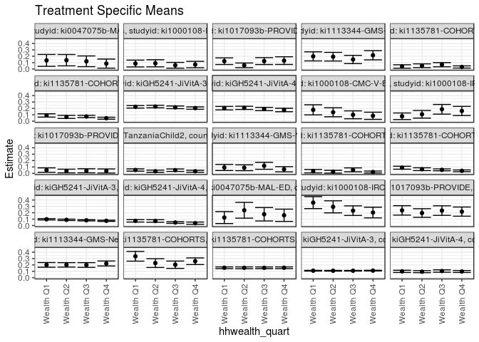

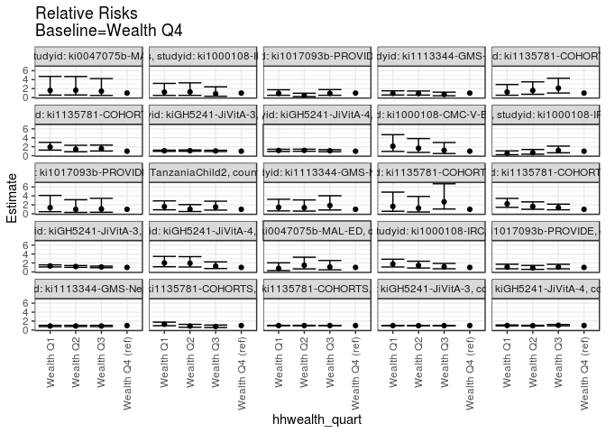

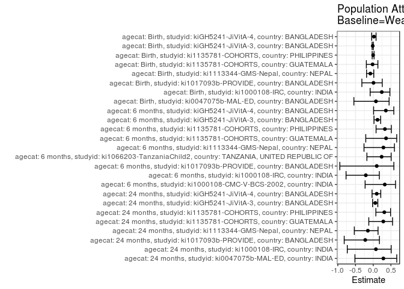

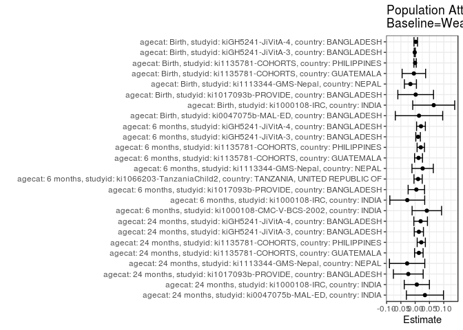

## Results Table

### Parameter: TSM

| agecat | studyid | country | intervention_level | baseline_level | estimate | ci_lower | ci_upper |
| --- | --- | --- | --- | --- | --- | --- | --- |
| Birth | ki0047075b-MAL-ED | BANGLADESH | Wealth Q4 | NA | 0.1607143 | 0.0642827 | 0.2571459 |
| Birth | ki0047075b-MAL-ED | BANGLADESH | Wealth Q1 | NA | 0.1250000 | 0.0312072 | 0.2187928 |
| Birth | ki0047075b-MAL-ED | BANGLADESH | Wealth Q2 | NA | 0.2391304 | 0.1155571 | 0.3627038 |
| Birth | ki0047075b-MAL-ED | BANGLADESH | Wealth Q3 | NA | 0.1764706 | 0.0715836 | 0.2813576 |
| Birth | ki1000108-IRC | INDIA | Wealth Q4 | NA | 0.2033202 | 0.1201522 | 0.2864882 |
| Birth | ki1000108-IRC | INDIA | Wealth Q1 | NA | 0.3590656 | 0.2656915 | 0.4524396 |
| Birth | ki1000108-IRC | INDIA | Wealth Q2 | NA | 0.2929889 | 0.1988337 | 0.3871440 |
| Birth | ki1000108-IRC | INDIA | Wealth Q3 | NA | 0.2332025 | 0.1580503 | 0.3083548 |
| Birth | ki1017093b-PROVIDE | BANGLADESH | Wealth Q4 | NA | 0.2181365 | 0.1463286 | 0.2899443 |
| Birth | ki1017093b-PROVIDE | BANGLADESH | Wealth Q1 | NA | 0.2372653 | 0.1633641 | 0.3111664 |
| Birth | ki1017093b-PROVIDE | BANGLADESH | Wealth Q2 | NA | 0.1961892 | 0.1283626 | 0.2640157 |
| Birth | ki1017093b-PROVIDE | BANGLADESH | Wealth Q3 | NA | 0.2344393 | 0.1597218 | 0.3091568 |
| Birth | ki1113344-GMS-Nepal | NEPAL | Wealth Q4 | NA | 0.2225455 | 0.1833381 | 0.2617529 |
| Birth | ki1113344-GMS-Nepal | NEPAL | Wealth Q1 | NA | 0.2010675 | 0.1647563 | 0.2373786 |
| Birth | ki1113344-GMS-Nepal | NEPAL | Wealth Q2 | NA | 0.2014613 | 0.1668734 | 0.2360492 |
| Birth | ki1113344-GMS-Nepal | NEPAL | Wealth Q3 | NA | 0.1995327 | 0.1630626 | 0.2360028 |
| Birth | ki1135781-COHORTS | GUATEMALA | Wealth Q4 | NA | 0.2583275 | 0.2062666 | 0.3103885 |
| Birth | ki1135781-COHORTS | GUATEMALA | Wealth Q1 | NA | 0.3359342 | 0.2596546 | 0.4122138 |
| Birth | ki1135781-COHORTS | GUATEMALA | Wealth Q2 | NA | 0.2293683 | 0.1609754 | 0.2977613 |
| Birth | ki1135781-COHORTS | GUATEMALA | Wealth Q3 | NA | 0.2036632 | 0.1462815 | 0.2610450 |
| Birth | ki1135781-COHORTS | PHILIPPINES | Wealth Q4 | NA | 0.1559498 | 0.1420320 | 0.1698677 |
| Birth | ki1135781-COHORTS | PHILIPPINES | Wealth Q1 | NA | 0.1558172 | 0.1419786 | 0.1696557 |
| Birth | ki1135781-COHORTS | PHILIPPINES | Wealth Q2 | NA | 0.1553884 | 0.1408603 | 0.1699165 |
| Birth | ki1135781-COHORTS | PHILIPPINES | Wealth Q3 | NA | 0.1554869 | 0.1417974 | 0.1691764 |
| Birth | kiGH5241-JiVitA-3 | BANGLADESH | Wealth Q4 | NA | 0.1111434 | 0.1057669 | 0.1165199 |
| Birth | kiGH5241-JiVitA-3 | BANGLADESH | Wealth Q1 | NA | 0.1099769 | 0.1043746 | 0.1155792 |
| Birth | kiGH5241-JiVitA-3 | BANGLADESH | Wealth Q2 | NA | 0.1090142 | 0.1034989 | 0.1145295 |
| Birth | kiGH5241-JiVitA-3 | BANGLADESH | Wealth Q3 | NA | 0.1093626 | 0.1039587 | 0.1147665 |
| Birth | kiGH5241-JiVitA-4 | BANGLADESH | Wealth Q4 | NA | 0.0973819 | 0.0818138 | 0.1129500 |
| Birth | kiGH5241-JiVitA-4 | BANGLADESH | Wealth Q1 | NA | 0.0990939 | 0.0816496 | 0.1165382 |

[output cut: 70 more lines]

### Parameter: E(Y)

| agecat | studyid | country | intervention_level | baseline_level | estimate | ci_lower | ci_upper |
| --- | --- | --- | --- | --- | --- | --- | --- |
| Birth | ki0047075b-MAL-ED | BANGLADESH | NA | NA | 0.1741294 | 0.1215730 | 0.2266857 |
| Birth | ki1000108-IRC | INDIA | NA | NA | 0.2682216 | 0.2212677 | 0.3151755 |
| Birth | ki1017093b-PROVIDE | BANGLADESH | NA | NA | 0.2199248 | 0.1846953 | 0.2551543 |
| Birth | ki1113344-GMS-Nepal | NEPAL | NA | NA | 0.2059282 | 0.1745993 | 0.2372572 |
| Birth | ki1135781-COHORTS | GUATEMALA | NA | NA | 0.2537723 | 0.2221611 | 0.2853834 |
| Birth | ki1135781-COHORTS | PHILIPPINES | NA | NA | 0.1556246 | 0.1424244 | 0.1688248 |
| Birth | kiGH5241-JiVitA-3 | BANGLADESH | NA | NA | 0.1096477 | 0.1045230 | 0.1147723 |
| Birth | kiGH5241-JiVitA-4 | BANGLADESH | NA | NA | 0.0994152 | 0.0840401 | 0.1147903 |
| 6 months | ki1000108-CMC-V-BCS-2002 | INDIA | NA | NA | 0.1250000 | 0.0911644 | 0.1588356 |
| 6 months | ki1000108-IRC | INDIA | NA | NA | 0.1323529 | 0.0994307 | 0.1652752 |
| 6 months | ki1017093b-PROVIDE | BANGLADESH | NA | NA | 0.0414594 | 0.0255348 | 0.0573839 |
| 6 months | ki1066203-TanzaniaChild2 | TANZANIA, UNITED REPUBLIC OF | NA | NA | 0.0430906 | 0.0342310 | 0.0519502 |
| 6 months | ki1113344-GMS-Nepal | NEPAL | NA | NA | 0.0904255 | 0.0667359 | 0.1141152 |
| 6 months | ki1135781-COHORTS | GUATEMALA | NA | NA | 0.0323974 | 0.0209875 | 0.0438073 |
| 6 months | ki1135781-COHORTS | PHILIPPINES | NA | NA | 0.0594974 | 0.0505830 | 0.0684118 |
| 6 months | kiGH5241-JiVitA-3 | BANGLADESH | NA | NA | 0.0845851 | 0.0797798 | 0.0893904 |
| 6 months | kiGH5241-JiVitA-4 | BANGLADESH | NA | NA | 0.0569712 | 0.0481278 | 0.0658146 |
| 24 months | ki0047075b-MAL-ED | INDIA | NA | NA | 0.1189427 | 0.0767376 | 0.1611478 |
| 24 months | ki1000108-IRC | INDIA | NA | NA | 0.0757946 | 0.0501131 | 0.1014762 |
| 24 months | ki1017093b-PROVIDE | BANGLADESH | NA | NA | 0.1070812 | 0.0818727 | 0.1322897 |
| 24 months | ki1113344-GMS-Nepal | NEPAL | NA | NA | 0.1868583 | 0.1522030 | 0.2215136 |
| 24 months | ki1135781-COHORTS | GUATEMALA | NA | NA | 0.0449331 | 0.0323731 | 0.0574931 |
| 24 months | ki1135781-COHORTS | PHILIPPINES | NA | NA | 0.0681911 | 0.0582056 | 0.0781766 |
| 24 months | kiGH5241-JiVitA-3 | BANGLADESH | NA | NA | 0.2180591 | 0.2081778 | 0.2279404 |
| 24 months | kiGH5241-JiVitA-4 | BANGLADESH | NA | NA | 0.1945032 | 0.1812962 | 0.2077102 |

### Parameter: RR

| agecat | studyid | country | intervention_level | baseline_level | estimate | ci_lower | ci_upper |
| --- | --- | --- | --- | --- | --- | --- | --- |
| Birth | ki0047075b-MAL-ED | BANGLADESH | Wealth Q4 | Wealth Q4 | 1.0000000 | 1.0000000 | 1.0000000 |
| Birth | ki0047075b-MAL-ED | BANGLADESH | Wealth Q1 | Wealth Q4 | 0.7777778 | 0.2975830 | 2.0328390 |
| Birth | ki0047075b-MAL-ED | BANGLADESH | Wealth Q2 | Wealth Q4 | 1.4879227 | 0.6740216 | 3.2846335 |
| Birth | ki0047075b-MAL-ED | BANGLADESH | Wealth Q3 | Wealth Q4 | 1.0980392 | 0.4718772 | 2.5550931 |
| Birth | ki1000108-IRC | INDIA | Wealth Q4 | Wealth Q4 | 1.0000000 | 1.0000000 | 1.0000000 |
| Birth | ki1000108-IRC | INDIA | Wealth Q1 | Wealth Q4 | 1.7660102 | 1.0994664 | 2.8366417 |
| Birth | ki1000108-IRC | INDIA | Wealth Q2 | Wealth Q4 | 1.4410218 | 0.8675941 | 2.3934509 |
| Birth | ki1000108-IRC | INDIA | Wealth Q3 | Wealth Q4 | 1.1469718 | 0.6939611 | 1.8957032 |
| Birth | ki1017093b-PROVIDE | BANGLADESH | Wealth Q4 | Wealth Q4 | 1.0000000 | 1.0000000 | 1.0000000 |
| Birth | ki1017093b-PROVIDE | BANGLADESH | Wealth Q1 | Wealth Q4 | 1.0876920 | 0.6913097 | 1.7113514 |
| Birth | ki1017093b-PROVIDE | BANGLADESH | Wealth Q2 | Wealth Q4 | 0.8993873 | 0.5579557 | 1.4497522 |
| Birth | ki1017093b-PROVIDE | BANGLADESH | Wealth Q3 | Wealth Q4 | 1.0747367 | 0.6797604 | 1.6992151 |
| Birth | ki1113344-GMS-Nepal | NEPAL | Wealth Q4 | Wealth Q4 | 1.0000000 | 1.0000000 | 1.0000000 |
| Birth | ki1113344-GMS-Nepal | NEPAL | Wealth Q1 | Wealth Q4 | 0.9034893 | 0.7740474 | 1.0545775 |
| Birth | ki1113344-GMS-Nepal | NEPAL | Wealth Q2 | Wealth Q4 | 0.9052590 | 0.7824585 | 1.0473322 |
| Birth | ki1113344-GMS-Nepal | NEPAL | Wealth Q3 | Wealth Q4 | 0.8965931 | 0.7649464 | 1.0508960 |
| Birth | ki1135781-COHORTS | GUATEMALA | Wealth Q4 | Wealth Q4 | 1.0000000 | 1.0000000 | 1.0000000 |
| Birth | ki1135781-COHORTS | GUATEMALA | Wealth Q1 | Wealth Q4 | 1.3004196 | 0.9627518 | 1.7565183 |
| Birth | ki1135781-COHORTS | GUATEMALA | Wealth Q2 | Wealth Q4 | 0.8878973 | 0.6222526 | 1.2669479 |
| Birth | ki1135781-COHORTS | GUATEMALA | Wealth Q3 | Wealth Q4 | 0.7883916 | 0.5598851 | 1.1101586 |
| Birth | ki1135781-COHORTS | PHILIPPINES | Wealth Q4 | Wealth Q4 | 1.0000000 | 1.0000000 | 1.0000000 |
| Birth | ki1135781-COHORTS | PHILIPPINES | Wealth Q1 | Wealth Q4 | 0.9991492 | 0.9567216 | 1.0434583 |
| Birth | ki1135781-COHORTS | PHILIPPINES | Wealth Q2 | Wealth Q4 | 0.9963999 | 0.9448092 | 1.0508078 |
| Birth | ki1135781-COHORTS | PHILIPPINES | Wealth Q3 | Wealth Q4 | 0.9970317 | 0.9537230 | 1.0423070 |
| Birth | kiGH5241-JiVitA-3 | BANGLADESH | Wealth Q4 | Wealth Q4 | 1.0000000 | 1.0000000 | 1.0000000 |
| Birth | kiGH5241-JiVitA-3 | BANGLADESH | Wealth Q1 | Wealth Q4 | 0.9895048 | 0.9610469 | 1.0188054 |
| Birth | kiGH5241-JiVitA-3 | BANGLADESH | Wealth Q2 | Wealth Q4 | 0.9808426 | 0.9532090 | 1.0092773 |
| Birth | kiGH5241-JiVitA-3 | BANGLADESH | Wealth Q3 | Wealth Q4 | 0.9839775 | 0.9564867 | 1.0122583 |
| Birth | kiGH5241-JiVitA-4 | BANGLADESH | Wealth Q4 | Wealth Q4 | 1.0000000 | 1.0000000 | 1.0000000 |
| Birth | kiGH5241-JiVitA-4 | BANGLADESH | Wealth Q1 | Wealth Q4 | 1.0175799 | 0.9183344 | 1.1275511 |

[output cut: 70 more lines]

### Parameter: PAR

| agecat | studyid | country | intervention_level | baseline_level | estimate | ci_lower | ci_upper |
| --- | --- | --- | --- | --- | --- | --- | --- |
| Birth | ki0047075b-MAL-ED | BANGLADESH | Wealth Q4 | NA | 0.0134151 | -0.0695286 | 0.0963588 |
| Birth | ki1000108-IRC | INDIA | Wealth Q4 | NA | 0.0649014 | -0.0085653 | 0.1383680 |
| Birth | ki1017093b-PROVIDE | BANGLADESH | Wealth Q4 | NA | 0.0017884 | -0.0606551 | 0.0642318 |
| Birth | ki1113344-GMS-Nepal | NEPAL | Wealth Q4 | NA | -0.0166172 | -0.0376679 | 0.0044334 |
| Birth | ki1135781-COHORTS | GUATEMALA | Wealth Q4 | NA | -0.0045552 | -0.0456727 | 0.0365622 |
| Birth | ki1135781-COHORTS | PHILIPPINES | Wealth Q4 | NA | -0.0003253 | -0.0044994 | 0.0038489 |
| Birth | kiGH5241-JiVitA-3 | BANGLADESH | Wealth Q4 | NA | -0.0014957 | -0.0034339 | 0.0004424 |
| Birth | kiGH5241-JiVitA-4 | BANGLADESH | Wealth Q4 | NA | 0.0020333 | -0.0041617 | 0.0082282 |
| 6 months | ki1000108-CMC-V-BCS-2002 | INDIA | Wealth Q4 | NA | 0.0407895 | -0.0107598 | 0.0923387 |
| 6 months | ki1000108-IRC | INDIA | Wealth Q4 | NA | -0.0276471 | -0.0886587 | 0.0333646 |
| 6 months | ki1017093b-PROVIDE | BANGLADESH | Wealth Q4 | NA | 0.0041459 | -0.0246054 | 0.0328972 |
| 6 months | ki1066203-TanzaniaChild2 | TANZANIA, UNITED REPUBLIC OF | Wealth Q4 | NA | 0.0102596 | -0.0041925 | 0.0247117 |
| 6 months | ki1113344-GMS-Nepal | NEPAL | Wealth Q4 | NA | 0.0261398 | -0.0111938 | 0.0634734 |
| 6 months | ki1135781-COHORTS | GUATEMALA | Wealth Q4 | NA | 0.0117484 | -0.0020944 | 0.0255913 |
| 6 months | ki1135781-COHORTS | PHILIPPINES | Wealth Q4 | NA | 0.0196493 | 0.0066958 | 0.0326028 |
| 6 months | kiGH5241-JiVitA-3 | BANGLADESH | Wealth Q4 | NA | 0.0102128 | 0.0022788 | 0.0181468 |
| 6 months | kiGH5241-JiVitA-4 | BANGLADESH | Wealth Q4 | NA | 0.0203365 | 0.0049922 | 0.0356809 |
| 24 months | ki0047075b-MAL-ED | INDIA | Wealth Q4 | NA | 0.0341970 | -0.0307412 | 0.0991351 |
| 24 months | ki1000108-IRC | INDIA | Wealth Q4 | NA | 0.0057946 | -0.0382574 | 0.0498467 |
| 24 months | ki1017093b-PROVIDE | BANGLADESH | Wealth Q4 | NA | -0.0240664 | -0.0761717 | 0.0280390 |
| 24 months | ki1113344-GMS-Nepal | NEPAL | Wealth Q4 | NA | -0.0281669 | -0.0899767 | 0.0336429 |
| 24 months | ki1135781-COHORTS | GUATEMALA | Wealth Q4 | NA | 0.0128343 | -0.0021425 | 0.0278111 |
| 24 months | ki1135781-COHORTS | PHILIPPINES | Wealth Q4 | NA | 0.0213790 | 0.0070559 | 0.0357020 |
| 24 months | kiGH5241-JiVitA-3 | BANGLADESH | Wealth Q4 | NA | 0.0128923 | -0.0032218 | 0.0290065 |
| 24 months | kiGH5241-JiVitA-4 | BANGLADESH | Wealth Q4 | NA | 0.0191693 | -0.0046701 | 0.0430087 |

### Parameter: PAF

| agecat | studyid | country | intervention_level | baseline_level | estimate | ci_lower | ci_upper |
| --- | --- | --- | --- | --- | --- | --- | --- |
| Birth | ki0047075b-MAL-ED | BANGLADESH | Wealth Q4 | NA | 0.0770408 | -0.5458102 | 0.4489274 |
| Birth | ki1000108-IRC | INDIA | Wealth Q4 | NA | 0.2419692 | -0.0866212 | 0.4711951 |
| Birth | ki1017093b-PROVIDE | BANGLADESH | Wealth Q4 | NA | 0.0081317 | -0.3206203 | 0.2550449 |
| Birth | ki1113344-GMS-Nepal | NEPAL | Wealth Q4 | NA | -0.0806943 | -0.1875665 | 0.0165601 |
| Birth | ki1135781-COHORTS | GUATEMALA | Wealth Q4 | NA | -0.0179501 | -0.1935794 | 0.1318363 |
| Birth | ki1135781-COHORTS | PHILIPPINES | Wealth Q4 | NA | -0.0020901 | -0.0292714 | 0.0243734 |
| Birth | kiGH5241-JiVitA-3 | BANGLADESH | Wealth Q4 | NA | -0.0136413 | -0.0315203 | 0.0039278 |
| Birth | kiGH5241-JiVitA-4 | BANGLADESH | Wealth Q4 | NA | 0.0204524 | -0.0433968 | 0.0803944 |
| 6 months | ki1000108-CMC-V-BCS-2002 | INDIA | Wealth Q4 | NA | 0.3263158 | -0.2283944 | 0.6305336 |
| 6 months | ki1000108-IRC | INDIA | Wealth Q4 | NA | -0.2088889 | -0.7673694 | 0.1731144 |
| 6 months | ki1017093b-PROVIDE | BANGLADESH | Wealth Q4 | NA | 0.1000000 | -0.9427092 | 0.5830565 |
| 6 months | ki1066203-TanzaniaChild2 | TANZANIA, UNITED REPUBLIC OF | Wealth Q4 | NA | 0.2380934 | -0.1780136 | 0.5072199 |
| 6 months | ki1113344-GMS-Nepal | NEPAL | Wealth Q4 | NA | 0.2890756 | -0.2599919 | 0.5988756 |
| 6 months | ki1135781-COHORTS | GUATEMALA | Wealth Q4 | NA | 0.3626352 | -0.2100558 | 0.6642850 |
| 6 months | ki1135781-COHORTS | PHILIPPINES | Wealth Q4 | NA | 0.3302547 | 0.0806692 | 0.5120812 |
| 6 months | kiGH5241-JiVitA-3 | BANGLADESH | Wealth Q4 | NA | 0.1207395 | 0.0221632 | 0.2093783 |
| 6 months | kiGH5241-JiVitA-4 | BANGLADESH | Wealth Q4 | NA | 0.3569614 | 0.0115912 | 0.5816522 |
| 24 months | ki0047075b-MAL-ED | INDIA | Wealth Q4 | NA | 0.2875078 | -0.5164954 | 0.6652512 |
| 24 months | ki1000108-IRC | INDIA | Wealth Q4 | NA | 0.0764516 | -0.7319580 | 0.5075275 |
| 24 months | ki1017093b-PROVIDE | BANGLADESH | Wealth Q4 | NA | -0.2247488 | -0.8191640 | 0.1754401 |
| 24 months | ki1113344-GMS-Nepal | NEPAL | Wealth Q4 | NA | -0.1507393 | -0.5337114 | 0.1366036 |
| 24 months | ki1135781-COHORTS | GUATEMALA | Wealth Q4 | NA | 0.2856317 | -0.1247612 | 0.5462841 |
| 24 months | ki1135781-COHORTS | PHILIPPINES | Wealth Q4 | NA | 0.3135153 | 0.0749475 | 0.4905573 |
| 24 months | kiGH5241-JiVitA-3 | BANGLADESH | Wealth Q4 | NA | 0.0591230 | -0.0178143 | 0.1302445 |
| 24 months | kiGH5241-JiVitA-4 | BANGLADESH | Wealth Q4 | NA | 0.0985551 | -0.0329076 | 0.2132860 |